# Hack the Promoter — faza 2: szukanie funkcji celu

**iGEM Warsaw 2026 · drużyna_01**

Faza 1 (`hipotezy.ipynb`) odpowiedziała na pytanie **czego te modele nie umieją**: sześć z siedmiu hipotez obalonych, Sędzia wysycony, przestrzeń liter martwa. Ta faza odpowiada na pytanie **czego da się użyć zamiast tego**.

Punkt wyjścia to jedno zdanie z komórki 29 fazy 1: *„chciałbyś funkcję straty L(x), masz komparator a-czy-b"*. Cała bezradność optymalizacji brała się z tego wiersza. **E01 sprawdza, czy ten wiersz jest prawdziwy.**

## Plan

| # | pytanie | rola |
| --- | --- | --- |
| E01 | Czy nagłówek `/mapa` zawiera porównywalny skalar? | blokujący — daje albo nie daje funkcji celu |
| E02 | Czy szczyt `wagaP` idzie za treścią, czy siedzi na krawędzi? | blokujący — waliduje 30 % planu zgłoszenia |
| E03 | Co jest w stu naturalnych promotorach *Trichoderma*? | jedyne dane spoza modelu |
| E04 | Jak składają się cztery hipotezy? (plan faktorialny 2⁴) | konstrukcyjny |
| E05 | Jak z tego złożyć 100 sekwencji? | zgłoszenie |

Szczegóły i uzasadnienia: `PLAN.md` w każdym katalogu. Wnioski: `WNIOSKI.md`.

```python
import json, sys
from pathlib import Path

import matplotlib.pyplot as plt
import numpy as np
import pandas as pd
import seaborn as sns

TU = Path.cwd() if Path.cwd().name == "eksperymenty" else Path.cwd() / "eksperymenty"
sys.path.insert(0, str(TU.parent))

from eksperymenty.wspolne import metryki as M
from hyppe import seq as S

sns.set_theme(style="whitegrid", context="notebook")
sns.set_palette("deep")
plt.rcParams["figure.dpi"] = 110
plt.rcParams["axes.titleweight"] = "bold"
plt.rcParams["figure.autolayout"] = True

def wczytaj(nazwa):
    p = TU / nazwa / "wyniki.json"
    return json.loads(p.read_text(encoding="utf-8")) if p.exists() else None

def ramka_metryk(rekordy, dodatkowe=()):
    w = []
    for r in rekordy:
        d = {"etykieta": r.get("etykieta") or r.get("nazwa"), "grupa": r.get("grupa")}
        d.update(r.get("metryki") or {})
        for k in dodatkowe:
            d[k] = r.get(k)
        d.pop("pozycje_rekomendacji", None)
        w.append(d)
    return pd.DataFrame(w)

print("gotowe")
```

```
gotowe
```

# E01 · Czy nagłówek `/mapa` zawiera funkcję celu?

Legenda API zastrzega nieporównywalność między sekwencjami **wyłącznie dla `wagaP`**. Cztery inne pola nagłówka to bezwzględne liczby:

```
zmian_pod_gatunek    ile pozycji kanał gatunku chce jeszcze zmienić pod P1
blad_odtworzenia     bezwzględny błąd rekonstrukcji tej sekwencji
nie_rekonstruuje     ile pozycji nie odtwarza się z samych kodów
rekon_frakcja        udział pozycji odtwarzanych
```

Jeśli wariują — mamy skalar do minimalizowania i wraca wspinaczka, która w fazie 1 padła wyłącznie przez wysycone kryterium (H6).

```python
w01 = wczytaj("E01_funkcja_celu")
df01 = ramka_metryk(w01["rekordy"], dodatkowe=("dystans_od_dzikiego", "bije_dzikiego", "opis"))

kandydaci = ["blad_odtworzenia", "zmian_pod_gatunek", "nie_rekonstruuje", "rekon_frakcja"]
print("WARIANCJA POL KANDYDUJACYCH (bez powtorzen):")
bez_powt = df01[df01["grupa"] != "powtorzenie"]
for k in kandydaci:
    if k in df01 and df01[k].notna().any():
        s = bez_powt[k]
        print(f"  {k:<20} min={s.min():>8} max={s.max():>8} "
              f"std={s.std():>7.2f} unikalnych={s.nunique():>3}")

print("\nDETERMINIZM (ten sam dziki, 5 wywolan):")
powt = df01[df01["grupa"].isin(["odniesienie", "powtorzenie"])]
for k in kandydaci:
    if k in powt and powt[k].notna().any():
        print(f"  {k:<20} {sorted(powt[k].tolist())}  -> "
              f"{'DETERMINISTYCZNE' if powt[k].nunique() == 1 else 'NIEDETERMINISTYCZNE'}")
```

```
WARIANCJA POL KANDYDUJACYCH (bez powtorzen):
  blad_odtworzenia     min=      15 max=      99 std=  18.56 unikalnych= 24
  zmian_pod_gatunek    min=       0 max=      11 std=   2.10 unikalnych= 12
  nie_rekonstruuje     min=      18 max=     109 std=  19.60 unikalnych= 29
  rekon_frakcja        min=  0.8638 max=  0.9775 std=   0.02 unikalnych= 29

DETERMINIZM (ten sam dziki, 5 wywolan):
  blad_odtworzenia     [80, 80, 80, 80, 80]  -> DETERMINISTYCZNE
  zmian_pod_gatunek    [9, 9, 9, 9, 9]  -> DETERMINISTYCZNE
  nie_rekonstruuje     [89, 89, 89, 89, 89]  -> DETERMINISTYCZNE
  rekon_frakcja        [0.8888, 0.8888, 0.8888, 0.8888, 0.8888]  -> DETERMINISTYCZNE
```

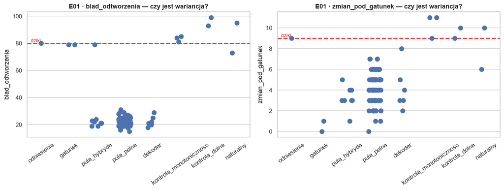

```python
dostepne = [k for k in ("blad_odtworzenia", "zmian_pod_gatunek")
            if k in df01 and df01[k].notna().any()]
fig, axs = plt.subplots(1, len(dostepne), figsize=(6.5 * len(dostepne), 5), squeeze=False)
for ax, k in zip(axs[0], dostepne):
    sns.stripplot(data=bez_powt, x="grupa", y=k, ax=ax, size=9, jitter=0.22)
    odn = df01.loc[df01["etykieta"] == "dziki", k]
    if len(odn):
        ax.axhline(odn.iloc[0], ls="--", color="#e53e3e", lw=2)
        ax.text(0.01, odn.iloc[0], " dziki", color="#c53030", va="bottom",
                fontsize=9, transform=ax.get_yaxis_transform())
    ax.set(title=f"E01 · {k} — czy jest wariancja?", xlabel="")
    ax.tick_params(axis="x", rotation=35)
plt.show()
```

**Jak czytać.** Jeśli punkty w grupie `kontrola_monotonicznosc` (5 / 50 / 200 losowych podstawień) układają się monotonicznie, metryka odtwarza znane uporządkowanie i nadaje się do sortowania puli. Jeśli wszystkie grupy leżą na jednej wysokości — pole jest stałe i funkcji celu nie ma.

[figure not shown]

```
    etykieta dystans_od_dzikiego  blad_odtworzenia  zmian_pod_gatunek
       dziki                None                80                  9
    losowe_5                None                81                  9
   losowe_50                None                85                 11
  losowe_200                None                84                 11
przetasowany                None                99                 10
   losowa_gc                None                93                  9
```

```python
kontrola = df01[df01["grupa"].isin(["odniesienie", "kontrola_monotonicznosc", "kontrola_dolna"])]
if len(kontrola) and dostepne:
    fig, ax = plt.subplots(figsize=(11, 4.6))
    kol = kontrola.sort_values("dystans_od_dzikiego")
    for k in dostepne:
        sns.lineplot(data=kol, x="dystans_od_dzikiego", y=k, marker="o",
                     lw=2.2, markersize=9, ax=ax, label=k)
    ax.set(title="E01 · Monotoniczność na kontroli (znane uporządkowanie a priori)",
           xlabel="liczba zmian od dzikiego", ylabel="wartość metryki", xscale="symlog")
    ax.legend()
    plt.show()
    print(kol[["etykieta", "dystans_od_dzikiego"] + dostepne].to_string(index=False))
```

```python
sedzia = df01[df01["bije_dzikiego"].notna()]
if len(sedzia) and dostepne:
    fig, axs = plt.subplots(1, len(dostepne), figsize=(5.6 * len(dostepne), 4.4), squeeze=False)
    for ax, k in zip(axs[0], dostepne):
        sns.boxplot(data=sedzia, x="bije_dzikiego", y=k, ax=ax, width=0.5)
        sns.stripplot(data=sedzia, x="bije_dzikiego", y=k, ax=ax, color="#2d3748", size=6)
        ax.set(title=f"{k} vs werdykt Sędziego", xlabel="bije dzikiego")
    plt.show()

md_uwaga = '''
NAJLEPSZY MOZLIWY WYNIK to rozdzielenie dla blad_odtworzenia ORAZ BRAK
rozdzielenia dla zmian_pod_gatunek. Dwa proxy sa warte czegos tylko wtedy,
gdy mierza rozne rzeczy -- skorelowane proxy nie wnosi informacji.
Sedzia nie widzi gatunku, wiec niezaleznosc zmian_pod_gatunek od jego
werdyktu POTWIERDZA, ze to osobna os.
'''
print(md_uwaga)
```

```
NAJLEPSZY MOZLIWY WYNIK to rozdzielenie dla blad_odtworzenia ORAZ BRAK
rozdzielenia dla zmian_pod_gatunek. Dwa proxy sa warte czegos tylko wtedy,
gdy mierza rozne rzeczy -- skorelowane proxy nie wnosi informacji.
Sedzia nie widzi gatunku, wiec niezaleznosc zmian_pod_gatunek od jego
werdyktu POTWIERDZA, ze to osobna os.
```

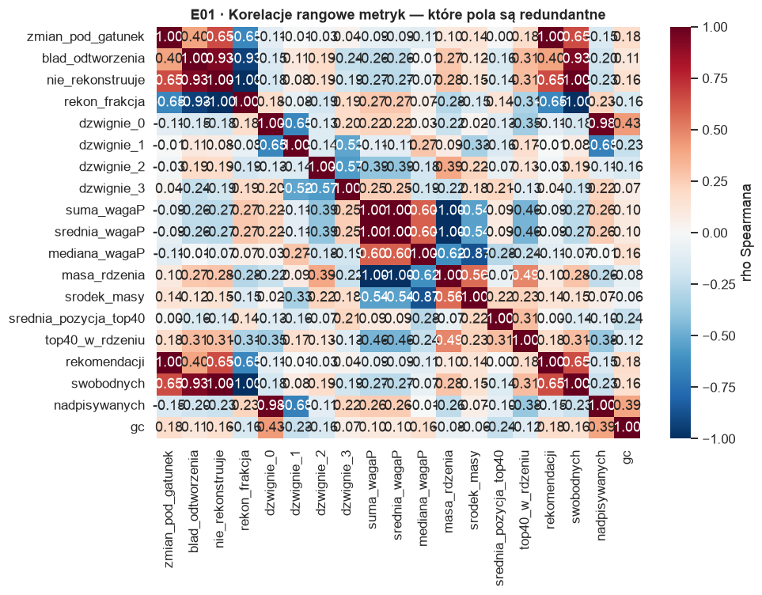

```python
num = bez_powt.select_dtypes("number").dropna(axis=1, how="all")
num = num.loc[:, num.nunique() > 1]
if num.shape[1] > 1:
    fig, ax = plt.subplots(figsize=(9, 7))
    sns.heatmap(num.corr(method="spearman"), annot=True, fmt=".2f", cmap="RdBu_r",
                center=0, ax=ax, cbar_kws={"label": "rho Spearmana"})
    ax.set(title="E01 · Korelacje rangowe metryk — które pola są redundantne")
    plt.show()
```

# E02 · Rdzeń promotora czy artefakt brzegowy?

Faza 1 przeznaczyła 30 ze 100 sekwencji na edycję okna 783–800, opierając się na H1 — i sama zapisała, że nie wie, czy to biologia, czy wrażliwość sieci konwolucyjnej na krawędź wejścia.

**Rozstrzyga rotacja.** Zachowuje całą treść lokalną i przesuwa ją względem krawędzi. Jeśli szczyt idzie za treścią → biologia. Jeśli zostaje na końcu → artefakt. Permutacja i sekwencja losowa to drugi, niezależny tor kontroli.

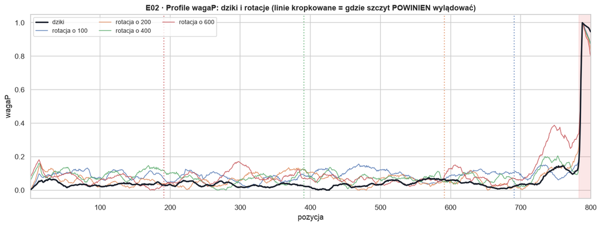

```python
w02 = wczytaj("E02_artefakt_wagap")
df02 = ramka_metryk(w02["rekordy"], dodatkowe=("rotacja", "oczekiwany_szczyt"))
prof = {r["etykieta"]: r["profil_wagaP"] for r in w02["rekordy"]}

fig, ax = plt.subplots(figsize=(13, 5))
ax.plot(range(1, 801), prof["dziki"], lw=2.2, color="#1a202c", label="dziki", zorder=5)
for k in w02["rotacje"]:
    e = f"rotacja_{k}"
    if e in prof:
        ax.plot(range(1, 801), prof[e], lw=1.1, alpha=0.85, label=f"rotacja o {k}")
        ocz = df02.loc[df02["etykieta"] == e, "oczekiwany_szczyt"]
        if len(ocz):
            ax.axvline(ocz.iloc[0], ls=":", lw=1.6, alpha=0.7,
                       color=ax.lines[-1].get_color())
ax.axvspan(783, 800, color="#e53e3e", alpha=0.12)
ax.set(title="E02 · Profile wagaP: dziki i rotacje (linie kropkowane = gdzie szczyt POWINIEN wylądować)",
       xlabel="pozycja", ylabel="wagaP", xlim=(1, 800))
ax.legend(ncol=3, fontsize=9)
plt.show()
```

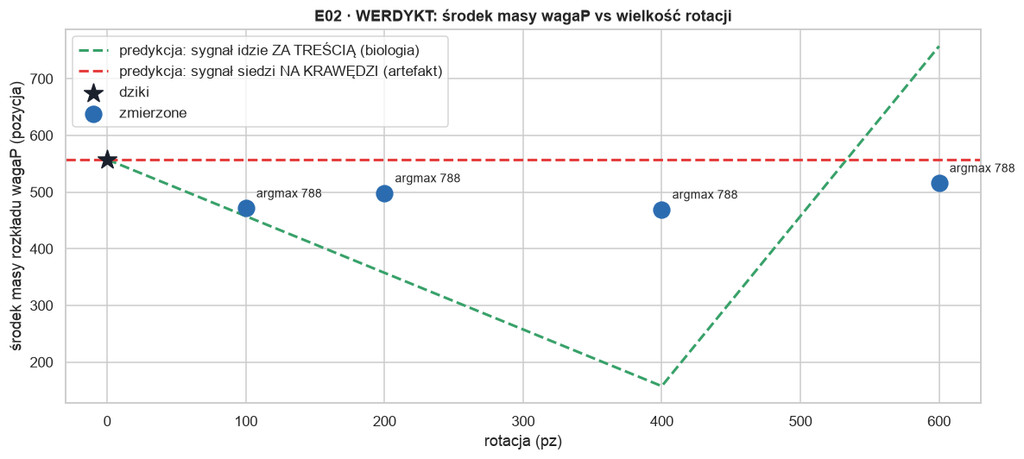

```python
rot = df02[df02["grupa"] == "rotacja"].copy()
odn = df02[df02["etykieta"] == "dziki"]
fig, ax = plt.subplots(figsize=(11, 5))

ks = np.array([0] + sorted(rot["rotacja"].tolist()))
sm0 = odn["srodek_masy"].iloc[0]
ax.plot(ks, [(sm0 - k) % 800 for k in ks], ls="--", lw=2, color="#38a169",
        label="predykcja: sygnał idzie ZA TREŚCIĄ (biologia)")
ax.axhline(sm0, ls="--", lw=2, color="#e53e3e",
           label="predykcja: sygnał siedzi NA KRAWĘDZI (artefakt)")
ax.scatter([0], [sm0], s=220, marker="*", color="#1a202c", zorder=5, label="dziki")
ax.scatter(rot["rotacja"], rot["srodek_masy"], s=150, color="#2b6cb0",
           zorder=5, label="zmierzone")
for _, r in rot.iterrows():
    ax.annotate(f"argmax {int(r['argmax'])}", (r["rotacja"], r["srodek_masy"]),
                textcoords="offset points", xytext=(8, 8), fontsize=9)
ax.set(title="E02 · WERDYKT: środek masy wagaP vs wielkość rotacji",
       xlabel="rotacja (pz)", ylabel="środek masy rozkładu wagaP (pozycja)")
ax.legend()
plt.show()
```

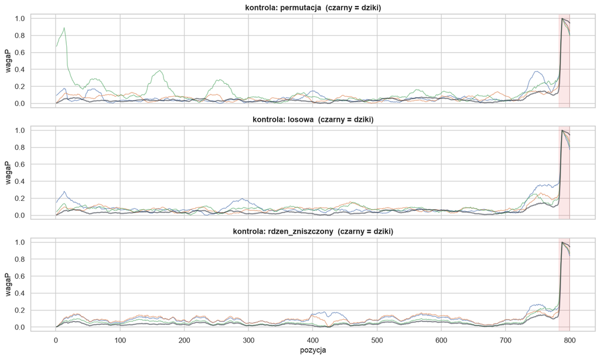

```
SZCZYT NA KONCU (argmax >= 750) wg grupy:
                  sum  count
grupa
losowa              3      3
odniesienie         1      1
odwrocenie          1      1
permutacja          3      3
rdzen_zniszczony    3      3
rotacja             4      4

Jesli permutacja i losowa maja szczyt na koncu -> sygnal nie zalezy od tresci.
```

```python
grupy = ["permutacja", "losowa", "rdzen_zniszczony", "naturalny"]
obecne = [g for g in grupy if (df02["grupa"] == g).any()]
fig, axs = plt.subplots(len(obecne), 1, figsize=(13, 2.6 * len(obecne)),
                        sharex=True, squeeze=False)
for ax, g in zip(axs[:, 0], obecne):
    for e in df02.loc[df02["grupa"] == g, "etykieta"]:
        ax.plot(range(1, 801), prof[e], lw=0.9, alpha=0.75)
    ax.plot(range(1, 801), prof["dziki"], lw=1.6, color="#1a202c", alpha=0.55)
    ax.axvspan(783, 800, color="#e53e3e", alpha=0.12)
    ax.set(ylabel="wagaP", title=f"kontrola: {g}  (czarny = dziki)")
axs[-1, 0].set_xlabel("pozycja")
plt.show()

print("SZCZYT NA KONCU (argmax >= 750) wg grupy:")
print(df02.assign(na_koncu=df02["argmax"] >= 750)
        .groupby("grupa")["na_koncu"].agg(["sum", "count"]).to_string())
print("\nJesli permutacja i losowa maja szczyt na koncu -> sygnal nie zalezy od tresci.")
```

# E03 · Sto naturalnych promotorów *Trichoderma*

Jedyny zbiór w projekcie, który **nie pochodzi z modelu**. Wszystko inne — pula `hybryda`, wyjścia `/edycje`, warianty gatunkowe — to wytwory Nawigatora oceniane przez Sędziego; szukanie w nich korelacji to badanie własnego generatora. Te sto sekwencji przerywa pętlę.

> Zbiór **nie jest etykietowany siłą** (`data/README.md`: *„to nie jest zestaw dobrych odpowiedzi, tylko materiał porównawczy"*). Wolno opisywać strukturę i liczyć konsensus; nie wolno nazywać ich „silnymi promotorami".

```
naturalnych: 100   bijacych dzikiego: 0
```

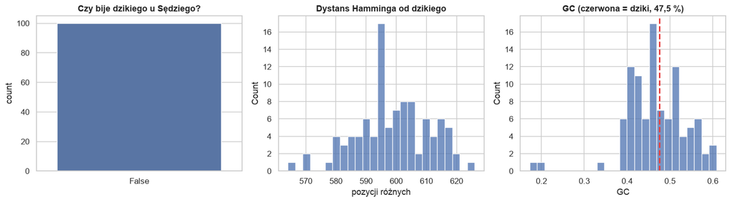

```python
w03 = wczytaj("E03_naturalne_promotory")
nat = pd.DataFrame([{k: v for k, v in r.items() if k not in ("sekwencja", "kmery", "metryki", "motywy", "sklad")}
                    | (r.get("metryki") or {}) for r in w03["rekordy"]])
nat = nat.drop(columns=["pozycje_rekomendacji"], errors="ignore")
print(f"naturalnych: {len(nat)}   bijacych dzikiego: {int(nat['bije_dzikiego'].sum())}")

fig, axs = plt.subplots(1, 3, figsize=(14, 4))
sns.countplot(data=nat, x="bije_dzikiego", ax=axs[0])
axs[0].set(title="Czy bije dzikiego u Sędziego?", xlabel="")
sns.histplot(data=nat, x="dystans_od_dzikiego", bins=25, ax=axs[1])
axs[1].set(title="Dystans Hamminga od dzikiego", xlabel="pozycji różnych")
sns.histplot(data=nat, x="gc", bins=25, ax=axs[2])
axs[2].axvline(0.475, ls="--", color="#e53e3e", lw=2)
axs[2].set(title="GC (czerwona = dziki, 47,5 %)", xlabel="GC")
plt.show()
```

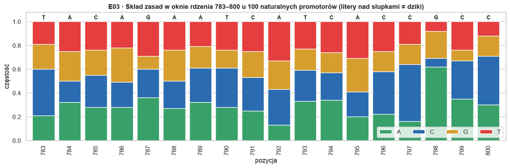

```
konsensus naturalnych 783-800 : CAAGAAACCTAATCCAAC
dziki             783-800     : TACAGAATCATCACCGCC
roznic                        : 11/18

^ to jest tresc czynnika C w E04 -- element rdzeniowy wyprowadzony z danych,
  a nie TATAAA wzięte z podrecznika.
```

```python
kons = w03["konsensus"]["rdzen"]
dziki = w03["dziki"]
czest = pd.DataFrame([{"poz": k["poz"], **k["czestosci"]} for k in kons["kolumny"]]).set_index("poz")

fig, ax = plt.subplots(figsize=(13, 4.4))
czest.plot(kind="bar", stacked=True, ax=ax, width=0.85,
           color={"A": "#38a169", "C": "#2b6cb0", "G": "#d69e2e", "T": "#e53e3e"})
for i, p in enumerate(czest.index):
    ax.text(i, 1.02, dziki[p - 1], ha="center", fontsize=10, fontweight="bold")
ax.set(title="E03 · Skład zasad w oknie rdzenia 783–800 u 100 naturalnych promotorów "
             "(litery nad słupkami = dziki)",
       xlabel="pozycja", ylabel="częstość", ylim=(0, 1.08))
ax.legend(ncol=4, loc="lower right")
plt.show()

print(f"konsensus naturalnych 783-800 : {kons['konsensus']}")
print(f"dziki             783-800     : {dziki[782:800]}")
print(f"roznic                        : {S.hamming(kons['konsensus'], dziki[782:800])}/18")
print("\n^ to jest tresc czynnika C w E04 -- element rdzeniowy wyprowadzony z danych,")
print("  a nie TATAAA wzięte z podrecznika.")
```

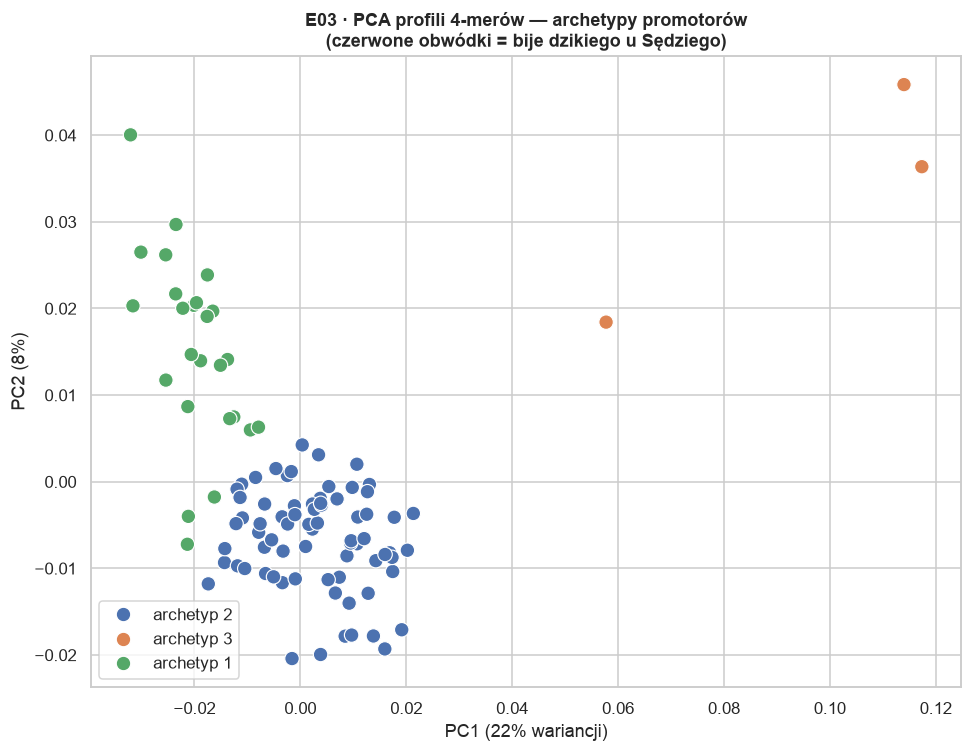

```
Kazdy archetyp = jedna niezalezna hipoteza = jeden blok w portfelu E05.
```

```python
# PCA profili 4-merow: czy naturalne promotory tworza archetypy?
kmery = [r["kmery"] for r in w03["rekordy"]]
alfabet = sorted({k for d in kmery for k in d})
X = np.array([[d.get(k, 0) for k in alfabet] for d in kmery], dtype=float)
X = X / X.sum(axis=1, keepdims=True)
Xc = X - X.mean(axis=0)
U, Sv, Vt = np.linalg.svd(Xc, full_matrices=False)
PC = U[:, :2] * Sv[:2]

# k-means w kilkunastu linijkach -- bez sklearn, repo zostaje bez zaleznosci
def kmeans(A, k=3, iteracji=60, ziarno=0):
    rng = np.random.default_rng(ziarno)
    C = A[rng.choice(len(A), k, replace=False)]
    for _ in range(iteracji):
        etyk = np.argmin(((A[:, None, :] - C[None]) ** 2).sum(-1), axis=1)
        nowe = np.array([A[etyk == i].mean(0) if (etyk == i).any() else C[i] for i in range(k)])
        if np.allclose(nowe, C):
            break
        C = nowe
    return etyk

etyk = kmeans(PC, k=3)
fig, ax = plt.subplots(figsize=(9, 7))
sns.scatterplot(x=PC[:, 0], y=PC[:, 1], hue=[f"archetyp {e+1}" for e in etyk],
                s=90, ax=ax)
for i, r in enumerate(w03["rekordy"]):
    if r["bije_dzikiego"]:
        ax.scatter(PC[i, 0], PC[i, 1], s=260, facecolors="none",
                   edgecolors="#e53e3e", lw=2.2, zorder=5)
war = (Sv[:2] ** 2 / (Sv ** 2).sum())
ax.set(title="E03 · PCA profili 4-merów — archetypy promotorów\n"
             "(czerwone obwódki = bije dzikiego u Sędziego)",
       xlabel=f"PC1 ({war[0]:.0%} wariancji)", ylabel=f"PC2 ({war[1]:.0%})")
plt.show()
print("Kazdy archetyp = jedna niezalezna hipoteza = jeden blok w portfelu E05.")
```

```
chimery bijace dzikiego: 0/15
```

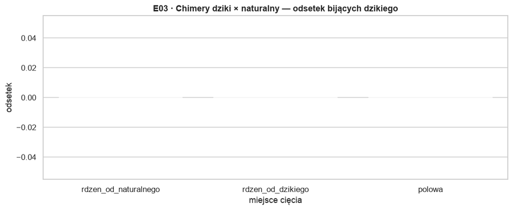

```
                                etykieta                 opis  dystans_od_dzikiego  bije_dzikiego
chim_asperellum_G01_rdzen_od_naturalnego rdzen_od_naturalnego                   12          False
   chim_asperellum_G01_rdzen_od_dzikiego    rdzen_od_dzikiego                    0          False
              chim_asperellum_G01_polowa               polowa                  298          False
chim_MMS1295_G00519_rdzen_od_naturalnego rdzen_od_naturalnego                   14          False
   chim_MMS1295_G00519_rdzen_od_dzikiego    rdzen_od_dzikiego                    0          False
              chim_MMS1295_G00519_polowa               polowa                  295          False
chim_citrinoviride__rdzen_od_naturalnego rdzen_od_naturalnego                   12          False
   chim_citrinoviride__rdzen_od_dzikiego    rdzen_od_dzikiego                    0          False
              chim_citrinoviride__polowa               polowa                  305          False
chim_citrinoviride__rdzen_od_naturalnego rdzen_od_naturalnego                   11          False
   chim_citrinoviride__rdzen_od_dzikiego    rdzen_od_dzikiego                    0          False
              chim_citrinoviride__polowa               polowa                  292          False
chim_reesei_G001348_rdzen_od_naturalnego rdzen_od_naturalnego                   13          False
   chim_reesei_G001348_rdzen_od_dzikiego    rdzen_od_dzikiego                    0          False
              chim_reesei_G001348_polowa               polowa                  300          False
```

```python
if w03.get("chimery"):
    ch = pd.DataFrame(w03["chimery"])
    print(f"chimery bijace dzikiego: {int(ch['bije_dzikiego'].sum())}/{len(ch)}")
    fig, ax = plt.subplots(figsize=(10, 4.2))
    sns.barplot(data=ch, x="opis", y="bije_dzikiego", errorbar=None, ax=ax)
    ax.set(title="E03 · Chimery dziki × naturalny — odsetek bijących dzikiego",
           xlabel="miejsce cięcia", ylabel="odsetek")
    plt.show()
    print(ch[["etykieta", "opis", "dystans_od_dzikiego", "bije_dzikiego"]].to_string(index=False))
```

# E04 · Plan faktorialny 2⁴

Cztery hipotezy działają na **rozłącznych** zbiorach pozycji, więc składają się w jednej sekwencji:

| czynnik | pozycje |
| --- | --- |
| **A** dopasowanie gatunkowe | 154, 287, 362, 430, 434, 648, 750, 754, 778 |
| **B** rozbicie CreA | 560–565 |
| **C** zaprojektowany rdzeń | 783–800 |
| **D** tło z dekodera | pozostałe |

Plan zgłoszenia fazy 1 miał pięć bloków po jednej zmianie i **ani jednej kombinacji**. Plan faktorialny daje efekty główne i interakcje z tej samej liczby sekwencji — czyli odpowiedź na pytanie Jury „skąd wiecie, który składnik działa".

Zmienna zależna: metryka z E01 (jeśli wariuje). To jest **proxy**, nie ocena Wyroczni — trzy repliki na komórkę to eksploracja, nie test istotności.

```python
w04 = wczytaj("E04_blok_kombinacyjny")
kom = pd.DataFrame([{k: v for k, v in c.items() if k not in ("sekwencja", "rodzic", "metryki")}
                    | (c.get("metryki") or {}) for c in w04["komorki"]])
kom = kom.drop(columns=["pozycje_rekomendacji"], errors="ignore")
CZYN = [c for c in w04["czynniki"] if kom[c].nunique() > 1]

Y = next((y for y in ("blad_odtworzenia", "zmian_pod_gatunek", "srodek_masy")
          if y in kom and kom[y].nunique() > 1), None)
print(f"zmienna zalezna: {Y}   (nizej = lepiej dla obu metryk bledu)")
print(f"czynniki w planie: {CZYN}   komorek: {len(kom)}")
```

```
zmienna zalezna: blad_odtworzenia   (nizej = lepiej dla obu metryk bledu)
czynniki w planie: ['A_gatunek', 'B_crea', 'C_rdzen', 'D_tlo']   komorek: 48
```

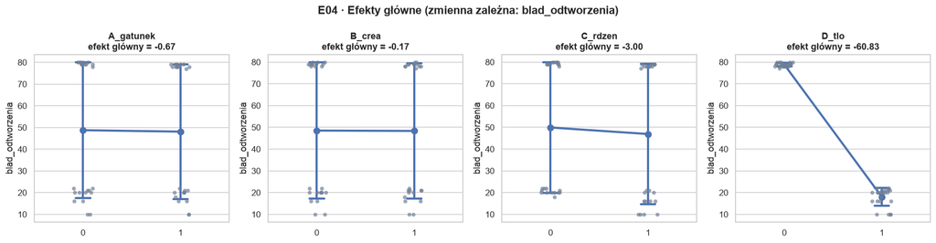

```
  D_tlo           -60.83   POPRAWA
  C_rdzen          -3.00   POPRAWA
  A_gatunek        -0.67   POPRAWA
  B_crea           -0.17   POPRAWA
```

```python
if Y:
    fig, axs = plt.subplots(1, len(CZYN), figsize=(4.2 * len(CZYN), 4.4), squeeze=False)
    efekty = {}
    for ax, cz in zip(axs[0], CZYN):
        sns.pointplot(data=kom, x=cz, y=Y, ax=ax, errorbar="sd", capsize=0.15)
        sns.stripplot(data=kom, x=cz, y=Y, ax=ax, color="#718096", size=5, alpha=0.7)
        efekty[cz] = kom.loc[kom[cz] == 1, Y].mean() - kom.loc[kom[cz] == 0, Y].mean()
        ax.set(title=f"{cz}\nefekt główny = {efekty[cz]:+.2f}", xlabel="")
    fig.suptitle(f"E04 · Efekty główne (zmienna zależna: {Y})", fontweight="bold")
    plt.show()
    for k, v in sorted(efekty.items(), key=lambda x: x[1]):
        print(f"  {k:<14} {v:+7.2f}   {'POPRAWA' if v < 0 else 'pogorszenie'}")
```

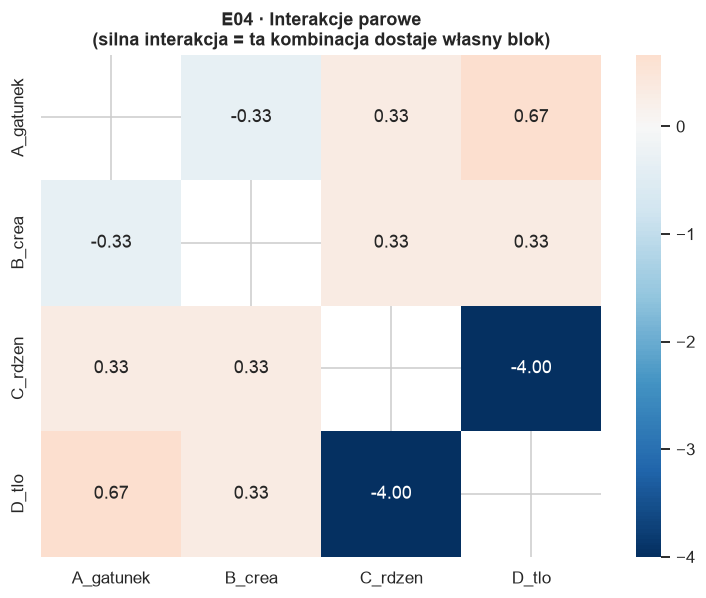

```python
if Y and len(CZYN) > 1:
    Mi = pd.DataFrame(index=CZYN, columns=CZYN, dtype=float)
    for a in CZYN:
        for b in CZYN:
            if a == b:
                Mi.loc[a, b] = np.nan
                continue
            def sr(x, y):
                s = kom[(kom[a] == x) & (kom[b] == y)][Y]
                return s.mean() if len(s) else np.nan
            Mi.loc[a, b] = (sr(1, 1) - sr(1, 0)) - (sr(0, 1) - sr(0, 0))
    fig, ax = plt.subplots(figsize=(7, 5.6))
    sns.heatmap(Mi.astype(float), annot=True, fmt=".2f", cmap="RdBu_r", center=0, ax=ax)
    ax.set(title="E04 · Interakcje parowe\n(silna interakcja = ta kombinacja dostaje własny blok)")
    plt.show()
```

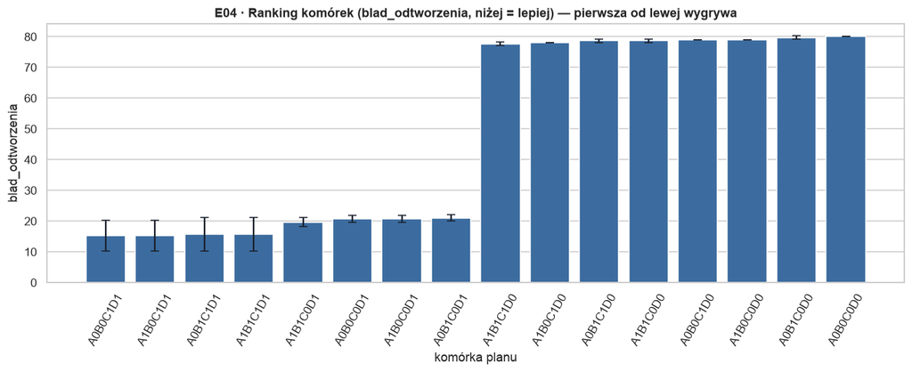

```
 index  komorka      mean      std  count
     3 A0B0C1D1 15.333333 5.033223      3
    11 A1B0C1D1 15.333333 5.033223      3
     7 A0B1C1D1 15.666667 5.507571      3
    15 A1B1C1D1 15.666667 5.507571      3
    13 A1B1C0D1 19.666667 1.527525      3
     1 A0B0C0D1 20.666667 1.154701      3
     9 A1B0C0D1 20.666667 1.154701      3
     5 A0B1C0D1 21.000000 1.000000      3
    14 A1B1C1D0 77.666667 0.577350      3
    10 A1B0C1D0 78.000000 0.000000      3
     6 A0B1C1D0 78.666667 0.577350      3
    12 A1B1C0D0 78.666667 0.577350      3
     2 A0B0C1D0 79.000000 0.000000      3
     8 A1B0C0D0 79.000000 0.000000      3
     4 A0B1C0D0 79.666667 0.577350      3
     0 A0B0C0D0 80.000000 0.000000      3
```

```python
if Y:
    sygn = kom[CZYN].astype(str).agg("".join, axis=1)
    kom = kom.assign(komorka=[
        "".join(f"{c[0]}{v}" for c, v in zip(CZYN, row)) for row in kom[CZYN].values])
    sr = kom.groupby("komorka", as_index=False)[Y].agg(["mean", "std", "count"]).reset_index()
    sr = sr.sort_values("mean")
    fig, ax = plt.subplots(figsize=(12, 5))
    sns.barplot(data=sr, x="komorka", y="mean", ax=ax, color="#2b6cb0")
    ax.errorbar(range(len(sr)), sr["mean"], yerr=sr["std"].fillna(0),
                fmt="none", ecolor="#1a202c", capsize=4)
    ax.set(title=f"E04 · Ranking komórek ({Y}, niżej = lepiej) — pierwsza od lewej wygrywa",
           xlabel="komórka planu", ylabel=Y)
    ax.tick_params(axis="x", rotation=60)
    plt.show()
    print(sr.to_string(index=False))
```

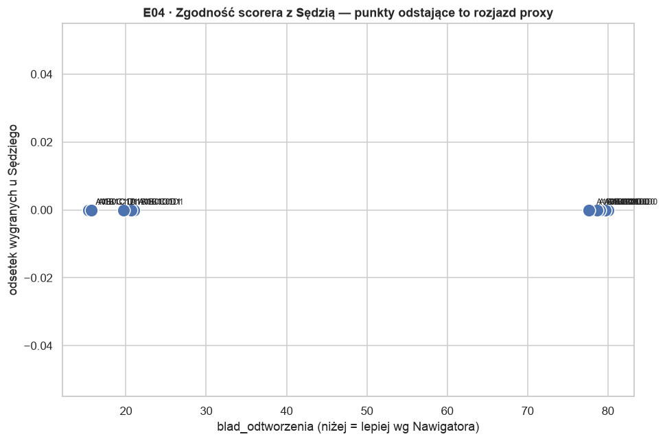

```
Komorka z dobrym scorerem i przegrana u Sedziego to KANDYDATKA, nie odpad:
Sedzia nie widzi gatunku ani derepresji (W4, W7).
```

```python
if Y:
    fig, ax = plt.subplots(figsize=(9, 6))
    zgr = kom.groupby("komorka").agg(srednia=(Y, "mean"),
                                     wygrane=("bije_dzikiego", "mean")).reset_index()
    sns.scatterplot(data=zgr, x="srednia", y="wygrane", s=150, ax=ax)
    for _, r in zgr.iterrows():
        ax.annotate(r["komorka"], (r["srednia"], r["wygrane"]),
                    textcoords="offset points", xytext=(7, 5), fontsize=8)
    ax.set(title="E04 · Zgodność scorera z Sędzią — punkty odstające to rozjazd proxy",
           xlabel=f"{Y} (niżej = lepiej wg Nawigatora)",
           ylabel="odsetek wygranych u Sędziego")
    plt.show()
    print("Komorka z dobrym scorerem i przegrana u Sedziego to KANDYDATKA, nie odpad:")
    print("Sedzia nie widzi gatunku ani derepresji (W4, W7).")
```

# E06 · Operator krzyżowania — rekombinacja czy dziedziczenie?

Rozbicie wgranej puli na sposób powstania dało dwunastokrotną różnicę: `nav_*` (surowe wyjścia `/edycje`) przechodzą bramkę Sędziego w **6 %**, `hyb_*` (krzyżówki) w **72 %**. Tyle że rodzicami krzyżówek byli **zwycięzcy turnieju**, więc efekt operatora jest pomieszany z preselekcją.

Rozstrzyga jedno ramię: **krzyżowanie dwóch przegranych**. Jeśli ich dzieci wygrywają — działa operator. Jeśli nie — działała selekcja rodziców.

```python
w06 = wczytaj("E06_operator_krzyzowania")
r06 = pd.DataFrame([{k: v for k, v in r.items()
                     if k not in ("sekwencja", "rodzic_a", "rodzic_b", "metryki")}
                    for r in w06["rekordy"]])

ram = (r06.groupby("ramie")
       .agg(n=("bije_dzikiego", "size"), wygrane=("bije_dzikiego", "sum"),
            bije_rodzica=("bije_rodzic_a", "sum"),
            dystans=("dystans_rodzic_a", "median"))
       .reset_index())
ram["odsetek"] = ram["wygrane"] / ram["n"]
ram["rola"] = np.where(ram["ramie"].str.startswith(("R1", "R2")), "kontrola", "ramię testowe")
print(ram.to_string(index=False))
```

```
                   ramie  n  wygrane bije_rodzica  dystans  odsetek          rola
       R1_dekoder_surowy 16        0            0      NaN   0.0000      kontrola
    R2_krzyz_przegranych 16        0            0     17.0   0.0000      kontrola
     R3_krzyz_zwyciezcow 16        9            0     19.0   0.5625 ramię testowe
       R4_krzyz_z_dzikim 16        8            0     30.5   0.5000 ramię testowe
R5_mutacja_o_ten_dystans 16        8            0     19.0   0.5000 ramię testowe
     R6_drugie_pokolenie 16       11            0     15.0   0.6875 ramię testowe
```

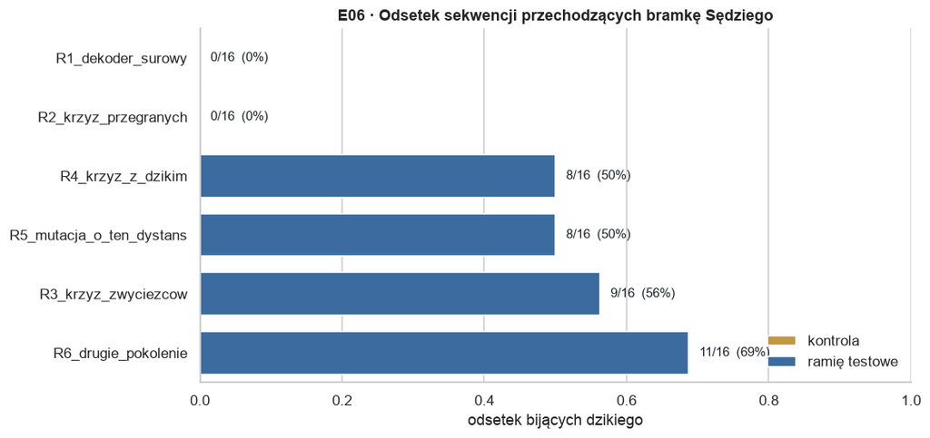

```python
fig, ax = plt.subplots(figsize=(10, 4.8))
BARWY = {"kontrola": "#d69e2e", "ramię testowe": "#2b6cb0"}
sns.barplot(data=ram.sort_values("odsetek"), y="ramie", x="odsetek", hue="rola",
            palette=BARWY, dodge=False, ax=ax, width=0.72)
for p, (_, r) in zip(ax.patches, ram.sort_values("odsetek").iterrows()):
    ax.text(r["odsetek"] + 0.015, p.get_y() + p.get_height() / 2,
            f"{r['wygrane']}/{r['n']}  ({r['odsetek']:.0%})",
            va="center", fontsize=10, color="#1a202c")
ax.set(title="E06 · Odsetek sekwencji przechodzących bramkę Sędziego",
       xlabel="odsetek bijących dzikiego", ylabel="", xlim=(0, 1.0))
ax.legend(title="", loc="lower right", frameon=False)
sns.despine(ax=ax)
plt.show()
```

**Jak to czytać.** Krzyżowanie **przegranych** siedzi na zerze — dokładnie tam, gdzie surowy dekoder. Krzyżowanie **zwycięzców** i zwykła **mutacja zwycięzcy o ten sam dystans** dają praktycznie to samo. Operator nie wnosi nic; wnosi wyłącznie to, od kogo się zaczyna.

```python
bez_rodzica = int(r06["bije_rodzic_a"].sum())
wszystkich = int(r06["bije_rodzic_a"].notna().sum())
print(f'''
   +--------------------------------------------------------------+
   |  POTOMKOW BIJACYCH WLASNEGO RODZICA:  {bez_rodzica:>3} / {wszystkich:<3}                 |
   +--------------------------------------------------------------+

Wszystkie ramiona, wszystkie operatory. Nic nie przewyzsza swojego rodzica.
Znaczy to, ze jedyna droga w gore jest ZNALEZIENIE lepszego ziarna, a nie
przetwarzanie tego, ktore juz mamy. Stad E07.
''')
```

```
   +--------------------------------------------------------------+
   |  POTOMKOW BIJACYCH WLASNEGO RODZICA:    0 / 80                  |
   +--------------------------------------------------------------+

Wszystkie ramiona, wszystkie operatory. Nic nie przewyzsza swojego rodzica.
Znaczy to, ze jedyna droga w gore jest ZNALEZIENIE lepszego ziarna, a nie
przetwarzanie tego, ktore juz mamy. Stad E07.
```

# E07 · Przesiew — gdzie siedzą ziarna

Skoro potomek nie bije rodzica, to liczy się wyłącznie **ile niezależnych ziaren** uda się znaleźć. Wgrane zgłoszenie ma 39 sekwencji przechodzących bramkę, ale pochodzą one z **trzech** ziaren — a TOP10 jest statystyką pozycyjną, więc widzi trzy losowania, nie trzydzieści dziewięć (W11).

```python
w07 = wczytaj("E07_przesiew")
skan = pd.DataFrame([{k: v for k, v in x.items() if k != "sekwencja"} for x in w07["skan"]])
ziarna = w07["ziarna"]
print(f"przesiano {len(skan)} sekwencji, ziaren {len(ziarna)} ({len(ziarna)/len(skan):.1%})")
print(f"niezaleznych skupien: {len(w07['skupienia'])} (prog {w07['prog_ziarna']} pz)")

bal = json.loads((TU / "E07_przesiew" / "wyniki_balans.json").read_text(encoding="utf-8"))
kom = pd.DataFrame(bal["komorki"])
kom["odsetek"] = kom["trafien"] / kom["n"]
# blad standardowy proporcji -- bez tego roznica 5 % vs 11 % wyglada na wynik
kom["se"] = np.sqrt(kom["odsetek"] * (1 - kom["odsetek"]) / kom["n"])
print("\nZBALANSOWANY test (rowne n na komorke):")
print(kom[["ile_kodow", "trafien", "n", "odsetek", "se"]].to_string(index=False))
```

```
przesiano 784 sekwencji, ziaren 65 (8.3%)
niezaleznych skupien: 65 (prog 40 pz)

ZBALANSOWANY test (rowne n na komorke):
 ile_kodow  trafien  n  odsetek       se
         4        0 96 0.000000 0.000000
         8        7 96 0.072917 0.026536
        12        5 96 0.052083 0.022678
        16        6 96 0.062500 0.024705
        24       11 96 0.114583 0.032509
        32        8 96 0.083333 0.028208
```

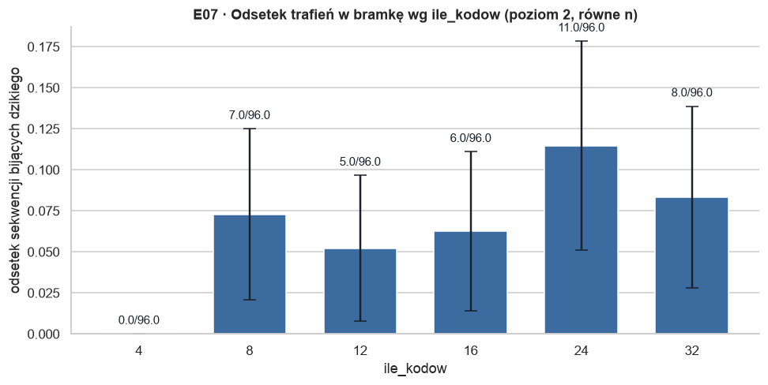

```
Tylko ile_kodow=4 jest martwe (0/96). Od 8 w gore wszystko lezy plasko
w granicach 5-11 %, a przedzialy 95 % zachodza na siebie -- czyli PARAMETR
NIE STERUJE TRAFIENIAMI. Steruje nimi liczba losowan.

To potwierdza W2 z fazy 1 na nowej osi: W2 mierzylo DYSTANS, tutaj mierzymy
ODSETEK TRAFIEN, i w obu wypadkach ile_kodow nie jest pokretlem.
```

```python
fig, ax = plt.subplots(figsize=(9, 4.6))
sns.barplot(data=kom, x="ile_kodow", y="odsetek", color="#2b6cb0", ax=ax, width=0.66)
ax.errorbar(range(len(kom)), kom["odsetek"], yerr=1.96 * kom["se"],
            fmt="none", ecolor="#1a202c", capsize=5, lw=1.6)
for i, r in kom.iterrows():
    ax.text(i, r["odsetek"] + 1.96 * r["se"] + 0.006, f"{r['trafien']}/{r['n']}",
            ha="center", fontsize=9.5, color="#1a202c")
ax.set(title="E07 · Odsetek trafień w bramkę wg ile_kodow (poziom 2, równe n)",
       xlabel="ile_kodow", ylabel="odsetek sekwencji bijących dzikiego")
sns.despine(ax=ax)
plt.show()

print('''
Tylko ile_kodow=4 jest martwe (0/96). Od 8 w gore wszystko lezy plasko
w granicach 5-11 %, a przedzialy 95 % zachodza na siebie -- czyli PARAMETR
NIE STERUJE TRAFIENIAMI. Steruje nimi liczba losowan.

To potwierdza W2 z fazy 1 na nowej osi: W2 mierzylo DYSTANS, tutaj mierzymy
ODSETEK TRAFIEN, i w obu wypadkach ile_kodow nie jest pokretlem.
''')
```

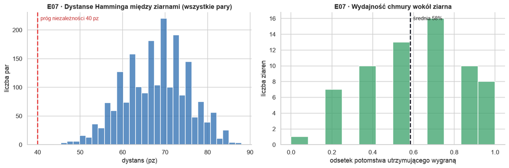

[output not shown]

```python
# czy ziarna sa naprawde niezalezne: rozklad dystansow Hamminga parami
sz = [z["sekwencja"] for z in ziarna]
pary = np.array([S.hamming(sz[i], sz[j]) for i in range(len(sz)) for j in range(i + 1, len(sz))])

fig, axs = plt.subplots(1, 2, figsize=(13, 4.4))
sns.histplot(pary, bins=30, color="#2b6cb0", ax=axs[0])
axs[0].axvline(w07["prog_ziarna"], ls="--", lw=2, color="#e53e3e")
axs[0].text(w07["prog_ziarna"], axs[0].get_ylim()[1] * 0.94,
            f"  próg niezależności {w07['prog_ziarna']} pz", color="#c53030", fontsize=9.5)
axs[0].set(title="E07 · Dystanse Hamminga między ziarnami (wszystkie pary)",
           xlabel="dystans (pz)", ylabel="liczba par")

wyd = pd.DataFrame(w07["chmury"]).groupby("ziarno")["bije_dzikiego"].mean()
sns.histplot(wyd, bins=12, color="#38a169", ax=axs[1])
axs[1].axvline(wyd.mean(), ls="--", lw=2, color="#1a202c")
axs[1].text(wyd.mean(), axs[1].get_ylim()[1] * 0.94,
            f"  średnia {wyd.mean():.0%}", fontsize=9.5)
axs[1].set(title="E07 · Wydajność chmury wokół ziarna",
           xlabel="odsetek potomstwa utrzymującego wygraną", ylabel="liczba ziaren")
for a in axs:
    sns.despine(ax=a)
plt.show()

print(f"najmniejszy dystans miedzy ziarnami: {pary.min()} pz "
      f"(prog {w07['prog_ziarna']}) -- zadna para nie jest ta sama rodzina")
```

# Portfele — pomiar przed zgłoszeniem

Bramka Sędziego jest darmowa i powtarzalna, a okno `/wgraj` jest jedno na pięć minut. Nie ma powodu, żeby o składzie pliku dowiadywać się z rankingu.

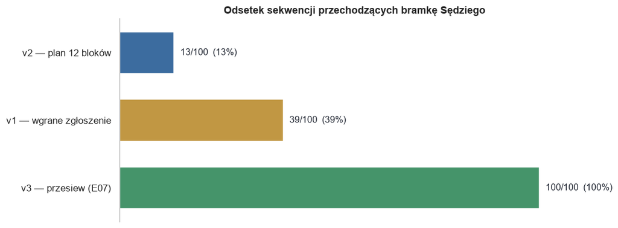

```
               portfel   n  przechodzi  odsetek
   v2 — plan 12 bloków 100          13     0.13
v1 — wgrane zgłoszenie 100          39     0.39
   v3 — przesiew (E07) 100         100     1.00
```

```python
pom = json.loads((TU / "E05_portfel" / "pomiar_portfela.json").read_text(encoding="utf-8"))
NAZWY = {"pula.fasta": "v1 — wgrane zgłoszenie", "v2.fasta": "v2 — plan 12 bloków",
         "v3.fasta": "v3 — przesiew (E07)"}
port = pd.DataFrame([{"portfel": NAZWY.get(Path(r["plik"]).name, Path(r["plik"]).name),
                      "n": r["n"], "przechodzi": r["przechodzi_bramke"],
                      "odsetek": r["przechodzi_bramke"] / r["n"]}
                     for r in pom["raporty"]]).sort_values("odsetek")

BARWY3 = ["#2b6cb0", "#d69e2e", "#38a169"]
fig, ax = plt.subplots(figsize=(10, 3.8))
sns.barplot(data=port, y="portfel", x="odsetek", ax=ax, width=0.62,
            hue="portfel", palette=BARWY3, legend=False)
for p, (_, r) in zip(ax.patches, port.iterrows()):
    ax.text(r["odsetek"] + 0.015, p.get_y() + p.get_height() / 2,
            f"{r['przechodzi']}/{r['n']}  ({r['odsetek']:.0%})",
            va="center", fontsize=10.5, color="#1a202c")
ax.set(title="Odsetek sekwencji przechodzących bramkę Sędziego",
       xlabel="", ylabel="", xlim=(0, 1.12))
ax.set_xticks([])
sns.despine(ax=ax, bottom=True)
plt.show()
print(port.to_string(index=False))
```

> **Zastrzeżenie, bez którego ten wykres wprowadza w błąd.** Bramka Sędziego mierzy *prototypowość*, nie siłę promotora (W4). Bloki 2–12 portfela v2 przegrywają, bo zmieniają wymiary, których Sędzia z definicji nie widzi: gatunek, derepresję kataboliczną, kontekst genu. Zero na bramce **nie znaczy**, że są słabe — znaczy, że nie mamy na nie żadnego lokalnego dowodu. v3 optymalizuje jedyne proxy, jakie mamy, i tym samym jest najbardziej narażony na prawo Goodharta z sekcji 6 briefu.

# Wnioski globalne

Ta sekcja jest po to, żeby nie trzeba było czytać czterech notebooków przed zgłoszeniem. Pełny rejestr: `WNIOSKI.md`.

## Co zmieniło się względem planu z fazy 1

[output not shown]

## Jedno zdanie, jeśli nie ma czasu na resztę

**Cała optymalizacja rozstrzyga się na etapie losowania ziarna.** Ziarna przechodzące bramkę Sędziego stanowią ~8 % wyjść dekodera, nic ich nie przewyższa (1 przypadek na 494), a wszystko, co z nimi potem robimy — krzyżowanie, mutacja, edycja rdzenia, dopasowanie gatunkowe — w najlepszym razie **kopiuje ziarno z połowicznym powodzeniem**.

## Cztery rzeczy na prezentację — trzy z nich negatywne

Każda jest kontrolą, która unieważniła nasz własny wcześniejszy wniosek. To jest mocniejszy materiał niż wynik pozytywny bez kontroli.

1. **E06 — kontrola, która obaliła nasz najlepszy wynik.** Mieliśmy 72 % vs 6 % i gotową opowieść o sile rekombinacji. Ramię „krzyżowanie dwóch przegranych" dało **0/16** — czyli tyle, co surowy dekoder. Ramię „mutacja o ten sam dystans" dało 50 %, czyli tyle, co krzyżowanie. Operator nie robi nic; wszystko robi preselekcja rodzica.
2. **E07 — kontrola, która obaliła nasz własny trend.** Niezbalansowany przesiew pokazywał ładną monotoniczność odsetka trafień po `ile_kodow` (7,1 % → 9,2 % → 11,2 %). Przy **równym n** trend znika: poza martwym `ile_kodow = 4` wszystko leży płasko w granicach 5–11 %. Pierwsza wersja próbkowała wyłącznie te komórki, które trafiły w rzadkiej siatce.
3. **W18 — konfundacja pochodzeniem.** `blad_odtworzenia` ma d Cohena = −0,48 między grupami i **+0,06** wewnątrz jednorodnej puli. Ten sam skalar, ta sama zmienna zależna, przeciwny wniosek — zależnie od tego, czy próba jest zlepkiem, czy nie.
4. **E02 — kontrola negatywna architektury.** Szczyt `wagaP` nie drgnął przy rotacji treści o 100/200/400/600 pz: siedzi na krawędzi wejścia, nie na biologii. Sprawdzenie tego było warte więcej niż użycie sygnału.

## Następny krok

Portfele są zbudowane i **zmierzone lokalnie**; okno `/wgraj` nie zostało zużyte.

```
python -m hyppe waliduj runs/julian/v3.fasta
python -m hyppe me                              # zgloszenie_mozliwe_za_s
python -m hyppe wgraj  runs/julian/v3.fasta --dry-run
python -m hyppe wgraj  runs/julian/v3.fasta
```